# FML_Assignment_4

2. Interpret the clusters with respect to the numerical variables used in forming the clusters. Is there a pattern in the clusters with respect to the numerical variables (10 to 12)? (those not used in forming the clusters)

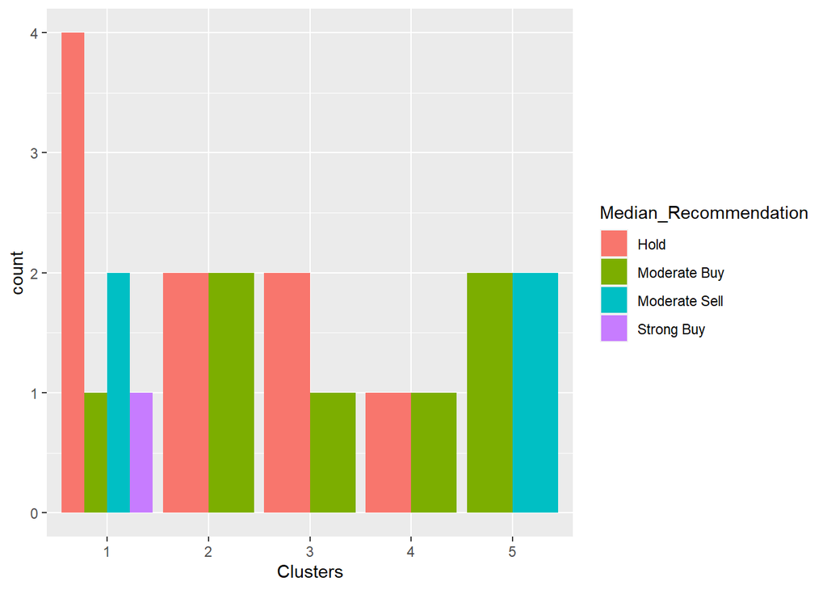

```r
rem_data <- p_data[12:14]
rem_data$Clusters <- k.means$cluster
ggplot(rem_data, aes(factor(Clusters), fill= Median_Recommendation))+ geom_bar(position='dodge')+labs(x='Clusters')
```

#from the above graph of the median recommendation there is a high possibility that the hold ones are in cluster one and as well has strong buy which the investors of large group will come into this cluster #from the second cluster the hold and moderate buy seems to be equal that meand it is moderate profit with leverage #from the third cluster there are both hold which is to be expected some growth and high risk and the investors will give less interest in it #from the fourth cluster there are hold and moderate profit and which is very less compared to other clusters #from the fifth cluster there are moderate profit and high leverage

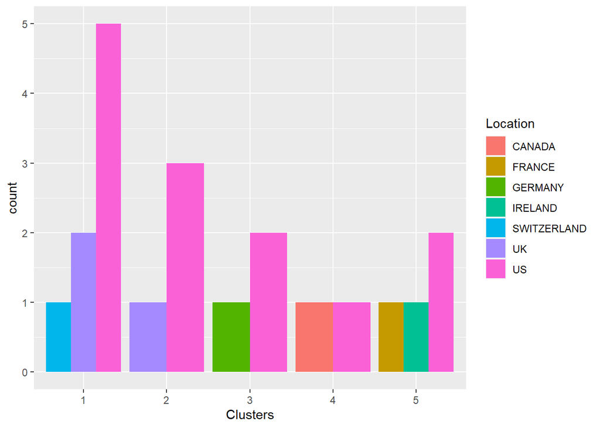

```r
ggplot(rem_data, aes(factor(Clusters), fill= Location))+ geom_bar(position='dodge')+labs(x='Clusters')
```

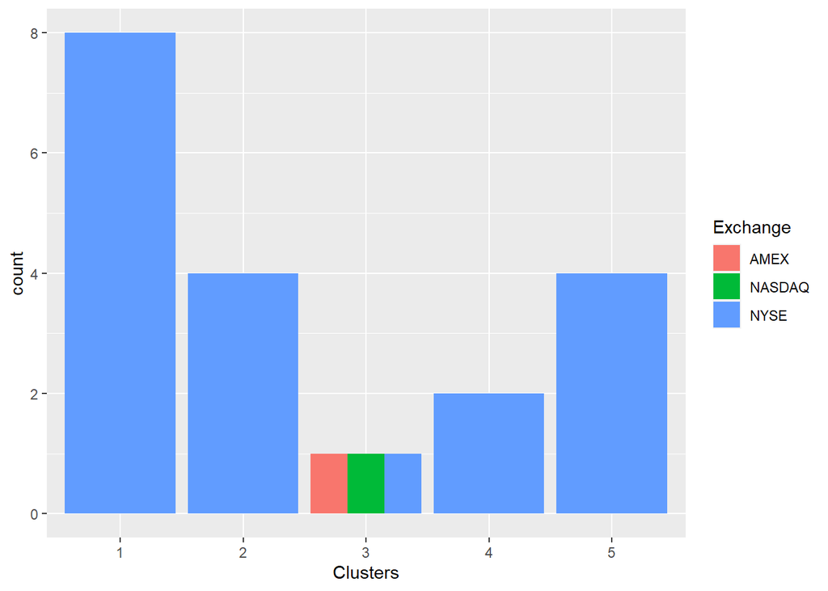

```r
ggplot(rem_data, aes(factor(Clusters), fill= Exchange))+ geom_bar(position='dodge')+labs(x='Clusters')
```

3. Provide an appropriate name for each cluster using any or all of the variables in the dataset.

#Cluster-1 Profitable companies #Cluster-2 High growth and potential companies #Cluster-3 Low Revenue companies #Cluster-4 Value companies #Cluster-5 Growth and Leveraged companies